## Aliyah in Numbers: The American Jewish Journey to Israel (2023–2024)

# Grop number 27

**Tamar Gershinsky**  
From : https://www.nbn.org.il/

```python
import pandas as pd
import numpy as np
import matplotlib.pyplot as plt
import seaborn as sns
from datetime import datetime
url = 'https://raw.githubusercontent.com/TamarG10/data-analysis-project/refs/heads/main/V2%20Olim%20from%20North%20America%202023-2024'
olim_df = pd.read_csv(url)
olim_df
```

|  | Date | Age | Source country | City in Israel | Profession | Gender | Family statos | Aliya statos | Date of interview | Year | Flight number | Religious affiliation | Academic degree | Unnamed: 13 |
| --- | --- | --- | --- | --- | --- | --- | --- | --- | --- | --- | --- | --- | --- | --- |
| 0 | 1/1/2023 | 1.0 | New York | Nahariyya | NaN | Female | Child | NaN | NaN | 2023.0 | NaN | Chabad | NaN | NaN |
| 1 | 1/1/2023 | 58.0 | Illinois | Jerusalem | Real Estate - Property Manager | Female | Married | Oleh | 1/13/2022 | 2023.0 | UA140 | Conservative | NaN | NaN |
| 2 | 1/1/2023 | 59.0 | Illinois | Jerusalem | Sales | Male | Married | Oleh | 1/13/2022 | 2023.0 | UA140 | Conservative | NaN | NaN |
| 3 | 1/1/2023 | 22.0 | New Jersey | Herzliya | NaN | Male | Single | NaN | NaN | 2023.0 | NaN | Reform | NaN | NaN |
| 4 | 1/2/2023 | 17.0 | New Jersey | Migdal Oz | Student | Female | Single | NaN | NaN | 2023.0 | NaN | Modern Orthodox | NaN | NaN |
| ... | ... | ... | ... | ... | ... | ... | ... | ... | ... | ... | ... | ... | ... | ... |
| 6765 | 12/31/2024 | 21.0 | Ontario | Ra'anana | Education - Early Childhood | Female | Single | Ezrach Oleh | 11/19/2024 | 2024.0 | LY28 | Modern Orthodox | NaN | NaN |
| 6766 | 12/31/2024 | 20.0 | British Columbia | Ra'anana | Unemployed | Male | Single | Katin Chozer | 11/20/2024 | 2024.0 | LY28 | Masorti | NaN | NaN |
| 6767 | 12/31/2024 | 20.0 | New York | NaN | Student | Female | Single | Oleh | 12/6/2024 | 2024.0 | LY28 | Modern Orthodox | NaN | NaN |
| 6768 | 12/31/2024 | 26.0 | Oregon | Tel Aviv-Yafo | Education - Elementary | Male | Single | Ezrach Oleh | 11/19/2024 | 2024.0 | LY06 | Other | NaN | NaN |
| 6769 | 12/31/2024 | 21.0 | New Jersey | Bet Shemesh | Management | Female | Married | Oleh | 11/4/2024 | 2024.0 | LY06 | Frum | NaN | NaN |

6770 rows × 14 columns

**נבצע מספר פעולות לתיקון הקובץ:**

1. נמחק את עמודה 13 הריקה
2. נשנה את עמודות התאריך לטיפוס (date) כדי שנוכל לעבוד איתם בהמשך
3. נשנה את כל תאי ה (nan) לערכים בעלי משמעות

```python
olim_df = olim_df.drop('Unnamed: 13', axis=1)
```

```python
olim_df['Date'] = pd.to_datetime(olim_df['Date'],format='%m/%d/%Y').dt.date
olim_df['Date of interview'] = pd.to_datetime(olim_df['Date of interview'] ,format='%m/%d/%Y').dt.date
```

```python
olim_df['Source country'] = olim_df['Source country'].fillna('Unknown')
olim_df['City in Israel'] = olim_df['City in Israel'].fillna('Unknown')
olim_df['Profession'] = olim_df['Profession'].fillna('None')
olim_df['Aliya statos'] = olim_df['Aliya statos'].fillna('-')
olim_df['Date of interview'] = olim_df['Date of interview'].fillna('-')
olim_df['Flight number'] = olim_df['Flight number'].fillna('-')
olim_df['Academic degree'] = olim_df['Academic degree'].fillna('None')
olim_df
```

|  | Date | Age | Source country | City in Israel | Profession | Gender | Family statos | Aliya statos | Date of interview | Year | Flight number | Religious affiliation | Academic degree |
| --- | --- | --- | --- | --- | --- | --- | --- | --- | --- | --- | --- | --- | --- |
| 0 | 2023-01-01 | 1.0 | New York | Nahariyya | None | Female | Child | - | - | 2023.0 | - | Chabad | None |
| 1 | 2023-01-01 | 58.0 | Illinois | Jerusalem | Real Estate - Property Manager | Female | Married | Oleh | 2022-01-13 | 2023.0 | UA140 | Conservative | None |
| 2 | 2023-01-01 | 59.0 | Illinois | Jerusalem | Sales | Male | Married | Oleh | 2022-01-13 | 2023.0 | UA140 | Conservative | None |
| 3 | 2023-01-01 | 22.0 | New Jersey | Herzliya | None | Male | Single | - | - | 2023.0 | - | Reform | None |
| 4 | 2023-01-02 | 17.0 | New Jersey | Migdal Oz | Student | Female | Single | - | - | 2023.0 | - | Modern Orthodox | None |
| ... | ... | ... | ... | ... | ... | ... | ... | ... | ... | ... | ... | ... | ... |
| 6765 | 2024-12-31 | 21.0 | Ontario | Ra'anana | Education - Early Childhood | Female | Single | Ezrach Oleh | 2024-11-19 | 2024.0 | LY28 | Modern Orthodox | None |
| 6766 | 2024-12-31 | 20.0 | British Columbia | Ra'anana | Unemployed | Male | Single | Katin Chozer | 2024-11-20 | 2024.0 | LY28 | Masorti | None |
| 6767 | 2024-12-31 | 20.0 | New York | Unknown | Student | Female | Single | Oleh | 2024-12-06 | 2024.0 | LY28 | Modern Orthodox | None |
| 6768 | 2024-12-31 | 26.0 | Oregon | Tel Aviv-Yafo | Education - Elementary | Male | Single | Ezrach Oleh | 2024-11-19 | 2024.0 | LY06 | Other | None |
| 6769 | 2024-12-31 | 21.0 | New Jersey | Bet Shemesh | Management | Female | Married | Oleh | 2024-11-04 | 2024.0 | LY06 | Frum | None |

6770 rows × 13 columns

```python
olim_df.columns
```

```
Index(['Date', 'Age', 'Source country', 'City in Israel', 'Profession',
       'Gender', 'Family statos', 'Aliya statos', 'Date of interview', 'Year',
       'Flight number', 'Religious affiliation', 'Academic degree'],
      dtype='object')
```

נבצע קורולציה , מכיוון שרוב המידע שלנו לא נומרי, לא נצליח להוציא כלום מהטבלה

```python
correlation_matrix = olim_df.corr(numeric_only = True, method = 'spearman' )
correlation_matrix
```

|  | Age | Year |
| --- | --- | --- |
| Age | 1.000000 | -0.033395 |
| Year | -0.033395 | 1.000000 |

## First part - Cities & Month under the influence of the war

- נייצר טבלה חדשה עם נתונים של סך העולים לכל עיר בחלוקה לפי שנים
- נייצר טבלה חדשה של חלוקת העולים לפי חודשים ולפי שנים
- נבחן אם רואים שינויים מה7.10.23
- נבחן ערים ספציפיות בדרום ובצפון

```python
olim_by_city = olim_df.groupby('City in Israel').size()
olim_by_city
```

```
City in Israel
Acco                1
Afula              39
Alon Shvut         22
Amirim              1
Arad                9
                   ..
Yakir               1
Yavne               9
Yehud               3
Yokne'am Illit      1
Zikhron Ya'akov    36
Length: 228, dtype: int64
```

```python
city_by_year_long = olim_df.groupby(['City in Israel', 'Year']).size().reset_index(name='Count')
city_by_year_long
sorted_df = city_by_year_long.sort_values('Count', ascending=False)
sorted_df
```

|  | City in Israel | Year | Count |
| --- | --- | --- | --- |
| 108 | Jerusalem | 2024.0 | 1156 |
| 107 | Jerusalem | 2023.0 | 979 |
| 37 | Bet Shemesh | 2024.0 | 455 |
| 302 | Tel Aviv-Yafo | 2024.0 | 388 |
| 36 | Bet Shemesh | 2023.0 | 347 |
| ... | ... | ... | ... |
| 183 | Manhattan | 2023.0 | 1 |
| 184 | Matityahu | 2023.0 | 1 |
| 187 | Mazkeret Batya | 2024.0 | 1 |
| 188 | Meitar | 2023.0 | 1 |
| 167 | Kochav Yair | 2024.0 | 1 |

335 rows × 3 columns

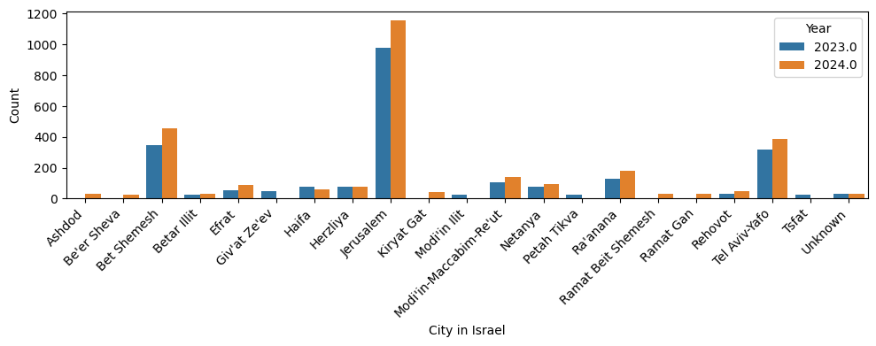

```python
filtered_df = city_by_year_long[city_by_year_long['Count'] > 25] #נבחר רק את הערים המשמעויתיות לטובת האסתטיקה
fig, axes = plt.subplots(figsize=(10, 4))

sns.barplot( data=filtered_df, x='City in Israel', y='Count', hue='Year')

plt.xlabel('City in Israel')
plt.ylabel('Count')
plt.xticks(rotation=45, ha='right')
plt.legend(title='Year')

plt.tight_layout()
plt.show()
```

```python
print(olim_df['Date'].dtype)
```

```
object
```

```python
olim_df['Date'] = pd.to_datetime(olim_df['Date'], format='%m/%d/%Y')
olim_df['Month'] = olim_df['Date'].dt.month
olim_by_month = olim_df.groupby(['Month', 'Year']).size().reset_index(name='Count')
olim_by_month = olim_by_month.drop([2 , 17, 26]) #מחיקת שורות עם טעות בשנים
olim_by_month
```

|  | Month | Year | Count |
| --- | --- | --- | --- |
| 0 | 1 | 2023.0 | 195 |
| 1 | 1 | 2024.0 | 190 |
| 3 | 2 | 2023.0 | 130 |
| 4 | 2 | 2024.0 | 182 |
| 5 | 3 | 2023.0 | 258 |
| 6 | 3 | 2024.0 | 151 |
| 7 | 4 | 2023.0 | 108 |
| 8 | 4 | 2024.0 | 180 |
| 9 | 5 | 2023.0 | 171 |
| 10 | 5 | 2024.0 | 206 |
| 11 | 6 | 2023.0 | 171 |
| 12 | 6 | 2024.0 | 254 |
| 13 | 7 | 2023.0 | 256 |
| 14 | 7 | 2024.0 | 457 |
| 15 | 8 | 2023.0 | 828 |
| 16 | 8 | 2024.0 | 901 |
| 18 | 9 | 2023.0 | 210 |
| 19 | 9 | 2024.0 | 456 |
| 20 | 10 | 2023.0 | 101 |
| 21 | 10 | 2024.0 | 167 |
| 22 | 11 | 2023.0 | 273 |
| 23 | 11 | 2024.0 | 221 |
| 24 | 12 | 2023.0 | 366 |
| 25 | 12 | 2024.0 | 333 |

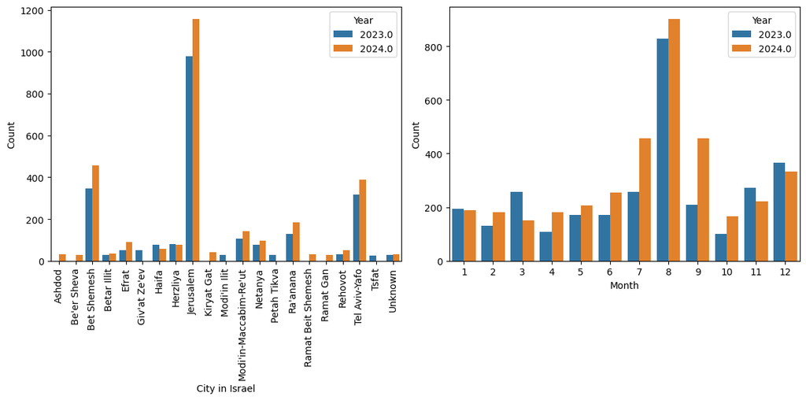

```python
filtered_df = city_by_year_long[city_by_year_long['Count'] > 25]
fig, axes = plt.subplots(figsize=(12, 6), ncols=2)

sns.barplot (data = filtered_df, x='City in Israel', y='Count', hue='Year', ax = axes[0])
axes[0].set_xticklabels(axes[0].get_xticklabels(), rotation=90)
sns.barplot (data = olim_by_month, x='Month', y='Count', hue='Year', ax = axes[1])

plt.tight_layout()
plt.show()
```

```python
print(olim_df['City in Israel'].unique())
```

```
['Nahariyya' 'Jerusalem' 'Herzliya' 'Migdal Oz' 'Or Akiva' 'Kibbutz Lavi'
 'Tel Aviv-Yafo' "Ra'anana" 'Beit Shean' "Kiryat Ye'arim" 'Ashkelon'
 'Rehovot' 'Modiin' 'Bat Yam' "Be'er Sheva" 'Yagur' 'Bnei Brak'
 'Matityahu' "Ma'ale Adumim" "Zikhron Ya'akov" 'Bet Shemesh' 'Betar Illit'
 'Tsfat' "Modi'in Ilit" 'Nof Hagalil' 'Rishon LeTsiyon' 'Efrat' 'Unknown'
 'Ashdod' 'Netanya' 'Beit El' 'Moshav Hadid' 'Beit Meir' "Pedu'el" 'Nirit'
 'Haifa' "Ma'ale Amos" 'Kfar Chabad' "Giv'at Shmuel" 'Holon' 'Afula'
 'Tirat Carmel' 'Mahseya' 'Ramat Gan' 'Pardes Hanna-Karkur'
 "Modi'in-Maccabim-Re'ut" 'Kibbutz Ramat Hakovesh' 'Ramat Beit Shemesh'
 'Kefar Sava' 'Yavne' 'Harish' 'Or Yehuda' 'Petah Tikva' 'Yad Binyamin'
 'Kfar Adumim' 'Arad' 'Moshav Kfar Pines' 'Eilat' 'Mesillat Ziyyon'
 'Ein HaHoresh' 'Karnei Shomron' 'Meitar' 'Manhattan' 'Mitzpe Ramon'
 'Kfar Masaryk' 'Kfar Tavor' 'Givon Hachadasha' 'Mevaseret Zion'
 'Kiryat Malachi' 'Bat Ayin' 'Dimona' 'Eshhar' "Hashmona'im" 'Kiryat Gat'
 'Retamim' 'Alon Shvut' "Ma'alot-Tarshiha" "Giv'at Ze'ev" 'Kiryat Bialik'
 'Kiryat Motzkin' 'Hatsor Ashdod' 'Kibbutz Ein Tzurim'
 'Kibbutz Ramat Yochanan' 'Neve Daniel' 'Sde Eliyahu' "Tsor'a"
 'Shavei Shomron' 'Moshav Ora' 'Avnei Chefetz' 'Rekhasim' 'Beit Dagan'
 'Nitzanei Oz' "Yokne'am Illit" 'Midreshet Ben-Gurion' 'Ramat Hasharon'
 'Atlit' 'Kibbutz Yizrael' 'Nes Tziona' 'Kibbutz Sasa' 'Kibbutz Gazit'
 'Migdal Haemek' 'Kiryat Ata' 'Caesarea' 'Kfar Eldad' "Be'erot Yitzhak"
 'Ofakim' 'Tzur Hadassah' "Kokhav Ya'akov" 'Ramot Hashavim' 'Qatsrin'
 'Tzur Yitzhak' 'Tel Mond' 'Mazkeret Batya' 'Givat Washington'
 "Giv'atayim" 'Ofra' 'Kibbutz Kfar Etzion' 'Bnei Dror' "Ma'on" 'Naan'
 'Tirat Zvi' 'Ben Shemen Youth Village' 'Gan Yavneh' 'Binyamina' 'Netivot'
 'Rosh Haayin' 'Nehusha' 'Eli' 'Elazar' "Ari'el" 'Metzad' 'Hadera'
 "Ma'agan Michael" 'Bet Arif' 'Naveh' 'Geva Binyamin' 'Moshav Salit'
 'Hispin' 'Talme Yosef' 'Hod HaSharon' 'Nof Ayalon' 'Dolev' 'Tzova'
 'Moshav Habonim' 'Kiryat Arba' 'Mitzpe Yeriho' 'Shiloh' 'Gedera'
 'Kerem Yavne (Yeshiva)' 'Moledet' 'Ein HaShofet' 'Tiberias' 'Shilo'
 'Kibbutz Hanaton' 'Shoham' 'Mitzpe Netofa' 'Moshav Hofit' 'Even Yehuda'
 'Kiryat Yam' 'Kibbutz Shoresh' 'Nofim' 'Poriya Kfar Avoda' 'Gvaot Eden'
 'Nordiyya' 'Karmiel' 'Porat' 'Kibbutz Ketura' 'Moshav Kerem Maharal'
 'Har Adar' 'Kiryat Ono' 'Emmanuel' 'Gan Ner' 'Acco' 'Yehud'
 'Kibbutz Afikim' 'Ganei Tikva' 'Moshav Matzliach' "Moshav Bnei Re'em"
 'Lod' 'Moshav Aderet' 'Tekoa' 'Amirim' 'Neve Michael' 'Kfar Vitkin'
 'Kfar Yehezkel' 'Elad' "Telz Stone (Kiryat Ye'arim)" 'Moshav Dor'
 'Kfar Yona' "Sha'alvim" 'Omer' 'Keshet' 'Ein Carmel' 'Shlomi'
 'Moshav Shefer' "Giv'at Hayyim (Ihud)" 'Burgeta' 'Ganei Modiin'
 'Kibbutz Ein Hamifratz' 'Kibbutz Afek' 'Kfar Giladi' 'Talmon'
 "Be'er Ya'akov" 'Ozem' 'Kfar Shmaryahu' 'Kibbutz Shomrat' 'Nesher'
 'Yakir' "Ma'ale Tzviya" 'Geulim' 'Kibbutz Shaar Haamakim' 'Haogen'
 'Ramla' "Be'er Milka" "Ma'galim" 'Kochav Yair' 'Tal El' 'Savyon' 'Azor'
 "Ma'Ale Levona" 'Elyakhin' 'Oranit' 'Moshav Yad Rambam'
 'Kibbutz Nir Yitzchak' 'Asfar' 'Nehora' 'Moshav Yinon' 'Gilon']
```

```python
selected_cities = ['Nahariyya', 'Kibbutz Lavi' , 'Ashkelon', 'Tsfat','Ofakim', 'Qatsrin', 'Haifa', 'Ashdod','Atlit']
filtered_df = city_by_year_long [city_by_year_long['City in Israel'].isin(selected_cities)]
filtered_df = filtered_df.drop(90)
filtered_df
```

|  | City in Israel | Year | Count |
| --- | --- | --- | --- |
| 11 | Ashdod | 2023.0 | 18 |
| 12 | Ashdod | 2024.0 | 33 |
| 13 | Ashkelon | 2023.0 | 15 |
| 14 | Ashkelon | 2024.0 | 24 |
| 15 | Atlit | 2023.0 | 3 |
| 16 | Atlit | 2024.0 | 2 |
| 91 | Haifa | 2023.0 | 76 |
| 92 | Haifa | 2024.0 | 58 |
| 139 | Kibbutz Lavi | 2023.0 | 3 |
| 140 | Kibbutz Lavi | 2024.0 | 12 |
| 226 | Nahariyya | 2023.0 | 10 |
| 227 | Nahariyya | 2024.0 | 2 |
| 248 | Ofakim | 2023.0 | 8 |
| 249 | Ofakim | 2024.0 | 1 |
| 267 | Qatsrin | 2023.0 | 6 |
| 268 | Qatsrin | 2024.0 | 6 |
| 311 | Tsfat | 2023.0 | 26 |
| 312 | Tsfat | 2024.0 | 19 |

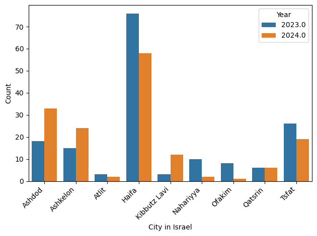

```python
sns.barplot (data = filtered_df, x='City in Israel', y='Count', hue='Year')
plt.xticks(rotation=45, ha='right')
plt.tight_layout()
plt.show()
```

## Secand part - Source country & City in Israel

- נייצר טבלה חדשה של המדינות מקור
- נשווה את מספר העולים לנתונים חיצוניים של ריכוז יהודים באותה מדינה
- נייצר טבלה שסוכמת התאמות בין מדינת מוצא לעיר בישראל אליה עלו
- נבחן אם יש התאמות בין מדינות שבהם גרים בריכוז לבין עליה מרוכזת לאותה עיר בישראל

```python
olim_by_Source = olim_df.groupby(['Source country']).size().reset_index(name='Count')
olim_by_Source
filtered_df = olim_by_Source [olim_by_Source ['Count'] > 50]
filtered_df = filtered_df.drop(66)
filtered_df
```

|  | Source country | Count |
| --- | --- | --- |
| 3 | Arizona | 57 |
| 10 | California | 606 |
| 11 | Colorado | 54 |
| 12 | Connecticut | 82 |
| 16 | Florida | 413 |
| 17 | Georgia | 68 |
| 21 | Illinois | 204 |
| 32 | Maryland | 273 |
| 33 | Massachusetts | 117 |
| 34 | Michigan | 77 |
| 43 | New Jersey | 761 |
| 45 | New York | 1428 |
| 49 | Ohio | 78 |
| 50 | Ontario | 315 |
| 53 | Pennsylvania | 177 |
| 55 | Quebec | 61 |
| 64 | Texas | 95 |
| 71 | Washington | 59 |

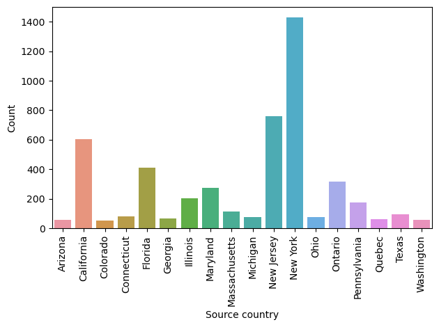

```python
sns.barplot(
    data= filtered_df ,
    x= 'Source country',
    y='Count',
)
plt.xticks(rotation=90)

plt.tight_layout()
plt.show()
```

```python
from IPython.display import Image
Image(url="https://raw.githubusercontent.com/TamarG10/data-analysis-project/main/Jews%20in%20America.jpeg")
```

[figure not shown]

```python
import matplotlib.pyplot as plt
City_olim_df = pd.DataFrame({
    'Source country',
    'City in Israel'
})

grouped = olim_df.groupby(['Source country', 'City in Israel']).size().reset_index(name='Count')
grouped
sorted_df = grouped.sort_values('Count', ascending=False)
sorted_df
cities_over_10 = grouped[grouped['Count'] > 10] # נזניח התאמות קטנות בשביל האסטתיקה
cities_over_10 = cities_over_10[cities_over_10['Source country'] != 'Unknown'] # נוריד מדינות לא ידועות
cities_over_10 = cities_over_10[cities_over_10['City in Israel'] != 'Unknown'] # נוריד ערים לא ידועות
cities_over_10
```

|  | Source country | City in Israel | Count |
| --- | --- | --- | --- |
| 15 | Arizona | Bet Shemesh | 22 |
| 18 | Arizona | Jerusalem | 16 |
| 37 | British Columbia | Jerusalem | 11 |
| 61 | California | Bet Shemesh | 28 |
| 67 | California | Ein HaHoresh | 18 |
| ... | ... | ... | ... |
| 812 | Pennsylvania | Tel Aviv-Yafo | 11 |
| 824 | Quebec | Jerusalem | 11 |
| 877 | Texas | Jerusalem | 25 |
| 893 | Texas | Tel Aviv-Yafo | 16 |
| 1010 | Washington | Jerusalem | 11 |

85 rows × 3 columns

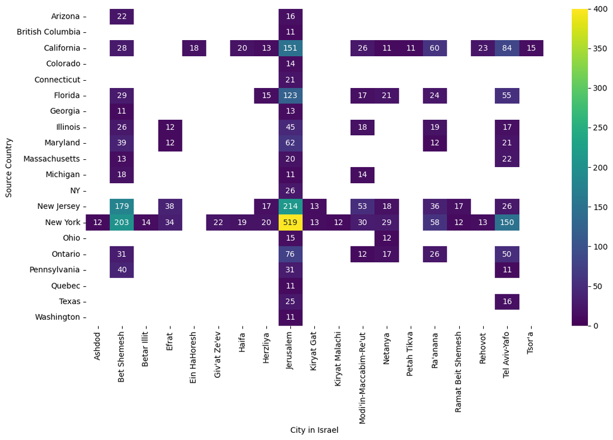

```python
pivot_df = cities_over_10.pivot(
    index='Source country',
    columns='City in Israel',
    values='Count'
)

plt.figure(figsize=(12, 8))
sns.heatmap(pivot_df, annot=True, fmt='.0f', cmap='viridis', vmin=0, vmax=400)
plt.xlabel('City in Israel')
plt.ylabel('Source Country')
plt.tight_layout()
plt.show()
```

## Last part - Age & Month

- נייצר טבלה חדשה של קבוצות גיל ונסכום אותם לפי חלוקה לשנים
- נבדוק האם יש הבדל בין השנים (נרצה לראות קפיצה משמעותית בצעירים של 2024 בגלל החיילים הבודדים)
- נייצר גרף עם חלוקה לחודשים לפי גילאים ונבדוק אם יש מגמה כלשהי

```python
bins = [0, 18, 30, 50, 70, 110]
labels = ['0-18', '18-30', '30-50', '50-70', '70-110']

olim_df['age_group'] = pd.cut(olim_df['Age'], bins=bins, labels=labels, right=False)

olim_by_age = olim_df.groupby(['age_group', 'Year']).size().reset_index(name='Count')
olim_by_age = olim_by_age.drop([0, 3, 4, 7, 8, 11, 12, 15, 16, 19])
olim_by_age
```

|  | age_group | Year | Count |
| --- | --- | --- | --- |
| 1 | 0-18 | 2023.0 | 670 |
| 2 | 0-18 | 2024.0 | 840 |
| 5 | 18-30 | 2023.0 | 1105 |
| 6 | 18-30 | 2024.0 | 1426 |
| 9 | 30-50 | 2023.0 | 578 |
| 10 | 30-50 | 2024.0 | 704 |
| 13 | 50-70 | 2023.0 | 407 |
| 14 | 50-70 | 2024.0 | 431 |
| 17 | 70-110 | 2023.0 | 304 |
| 18 | 70-110 | 2024.0 | 294 |

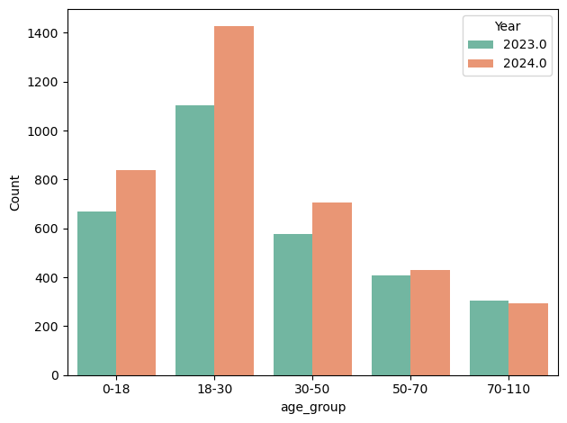

```python
age_by_month = olim_df.groupby(['age_group', 'Month']).size().reset_index(name='Count')
age_by_month

sns.barplot(
    data= olim_by_age,
    x= 'age_group',
    y='Count',
    hue='Year',
    palette='Set2'
)

plt.tight_layout()
plt.show()
```

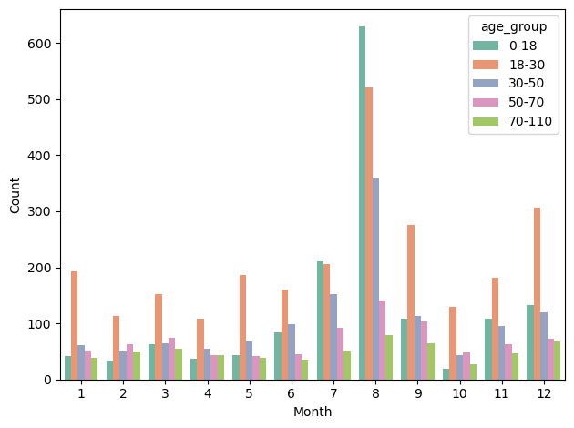

```python
sns.barplot(
    data= age_by_month,
    x= 'Month',
    y='Count',
    hue='age_group',
    palette='Set2'
)

plt.tight_layout()
plt.show()
```

### Observation 3:

מהגרף הראשון ניתן לראות כמו שצפינו שהיתה עליה משמעותית בשכבת גיל 18-30 ב2024 עקב הגיוס. בנוסף, ניתן ללמוד מהגרף שמגיל 50 ומעלה המספרים נמוכים משמעותית וצריך להבין איך מגיעים לקהל יעד הזה ומגדילים שם את הנתונים.  
מהגרף השני ניתן לראות מספר מסקנות מעניינות-

1. בשכבת הגיל המבוגרת המספרים נשארים די קבועים לאורך כל השנה
2. בחודשי הקיץ יש עליה משמעותית מאד בגיל הצעיר, מה שמעיד על משפחות שעולות בחופש ומנצלות את המעבר בין השנים